Coloration : algorithme de Brelaz

Par GUPTA Varun Vedic et HUYNH Alexandre du groupe Cygnus, en BUT Info.

# Introduction

Dans le cadre de la SAE "Exploration algorithmique d'un problème", nous avons dû réaliser un projet mathématique et informatique. Après réflexion et concertation avec notre professeur référent M. Borino, nous avons choisi de réaliser le projet Coloration: Algorithme de Brelaz.

Description:

- **Niveau :** ☆☆
- **Description :** Nous avons vu en cours un algorithme heuristique permettant d'estimer le nombre chromatique d'un graphe non orienté.
- **Animation :** la coloration des différents sommets d'un graphe.

Nous avons rédigé un notebook comprenant différents éléments (problématique, exposé de mathématiques, une solution Python à la question et pour finir une animation illustrant la résolution du problème). Nous avons réparti notre projet d'une durée totale estimée à 20h de la manière suivante:

- **Gupta Varun Vedic:** Rédaction du rapport & Animation de l'algorithme
- **Huynh Alexandre:** Mise en forme de l'algorithme en code Python & Animation

Bien évidemment, nous avons travaillé ensemble et nous nous sommmes entraidés sur les différentes étapes du projet (échanger et partager le code Python etc.) via la plateforme de messagerie instantanée Discord.

### Problématique: comment estimer le nombre chromatique à partir d'un graphe non-orienté?

# Sommaire

1. Haut de page
2. Histoire
3. Principe de l'algorithme
4. Fonctionnement de l'algorithme
5. Code Python
   1. Bibliothèques
   2. Matrice
   3. Algorithme de Brelaz
   4. Représentation graphique
   5. Fonctions réunies

Histoire

Les premiers résultats concernant la coloration des graphes touchaient essentiellement **la coloration des cartes**. Plus précisemment en 1852 où le mathématicien sud-africain et botaniste **Francis Guthrie** conjecture **le théorème des 4 couleurs** en cherchant à mettre en couleur une carte d’Angleterre. Ce théorème énonce qu’**il n’y avait besoin que de quatre couleurs pour que deux comtés ayant une frontière commune soient de couleurs différentes**. Bien plus tard en 1879, le mathématicien anglais **Alfred Kempe** publia une "démonstration" de ce théorème.

Cependant 10 années plus tard, un autre mathématicien anglais du nom de **Percy John Heawood** réfute la démonstration de Kempe et met en place le **théorème des 5 couleurs** en s’inspirant de la démonstration de Kempe. De nombreuses améliorations et avancées ont permis de **réduire le nombre de couleurs à quatre**.

En 1976 (presque un siècle plus tard), le mathématicien américain **Kenneth Appel** et le mathématicien allemand **Wolfgang Haken** ont pu démontrer ce **théorème des 4 couleurs**. Notons aussi que la démonstration, plus précisément les preuves des deux mathématiciens a été fortement appuyée par **l’ordinateur** (c’est la première fois que l’ordinateur a été autant utilisé).Cette coloration des graphes n’intervient pas seulement dans les cartes mais aussi dans les domaines de **la cryptographie, réseaux** etc. (dans un premier but précis l’optimisation de ces derniers). Il faut se mettre d’accord sur le fait qu’il est **impossible** de déterminer **le nombre chromatique d’un graphe**. Il faut donc bien évidemment **l’encadrer** avec un **minorant** et **majorant**. Pour se faire, il existe différents algorithmes de coloration tel que l’algorithme RLF, glouton mais nous allons voir plus nettement **l’algorithme de Brélaz**. </p>

Principe de l'algorithme

Soit G=(V,E) un graphe **connexe** et **non orienté** avec V l’ensemble des sommets et E l’ensemble des arêtes, on cherche à déterminer l’ordre de coloration du graphe. Pour se faire, on calcule le **degré de saturation** pour chaque sommet v de V (aussi le degré des sommets). Lorsque **tous les sommets de G sont coloriés**, l’algorithme de Brélaz est **terminé**. On note que l’algorithme est **séquentiel**, c'est-à-dire qu’elle colore un seul sommet non colorié à la fois. Rappelons ce qu’un graphe connexe, un graphe est connexe si elle possède qu’**une seule composante connexe** : Soit x un sommet d'un graphe G. La composante connexe de x est le sous-graphe de G engendré par Γ+(x,|G|)=Γ−(x,|G|). On le note CC(x,G)). Pour finir rappelons ce qu’est un graphe non orienté,un graphe non orienté G est la donnée de :

- Un ensemble fini et non vide noté **Som(G)** appelé les **sommets** du graphe G.
- Un ensemble noté **Ar(G)** appelé les **arêtes** du graphe G dont les éléments sont des ensembles formés de deux éléments de Som(G).

Fonctionnement de l'algorithme

L’algorithme de Brélaz fonctionne d’une manière particulière.

Soit G=(V,E) un graphe connexe et non orienté avec V l’ensemble des sommets et E l’ensemble des arêtes.

Il faut tout d’abord trouver **les degrés de chaque sommet** du graphe G.

Ensuite, il faut **trier** les sommets dans **l’ordre décroissant des degrés**, c’est-à-dire du plus grand degré au plus petit. Pour chaque sommet v de V, on initialise le **DSAT[v] = degré de v**. On commence en coloriant le premier DSAT maximal avec la couleur 1. On fait les étapes suivantes jusqu’à que tous les **sommets de G** sont **coloriés**.

Pour chaque sommet de G non colorié, il faut voir s'il y a un **voisin de x colorié**, c’est-à-dire si **les sommets adjacent au sommet sont coloriés**. Si c’est le cas, le **DSAT[v]** est égal au **nombre de sommet adjacent de v qui sont coloriés**. Si ce n’est pas le cas, le **DSAT[v] est égal au degré de v**.

On choisit le sommet non colorié ayant le **DSAT le plus grand**, en cas d’égalité on choisit le sommet ayant le **degré maximal**. Bien évidemment, on colorie le sommet avec **la plus petite couleur possible**, c'est-à-dire qu'en cas de conflit de couleur avec un autre sommet adjacent colorié, on prendra une autre couleur.

L’algorithme prend fin lorsque **tous les sommets** du graphe G sont **coloriés**. </p>

Code Python

# Bibliothèques

Les bibliothèques Python suivantes seront utilisés pour l'exécution de cet algorithme.

```python
# pour l'utilisation de la valeur pi, qui servira à la représentation des graphes
from math import *

# pour la génération aléatoire des valeurs d'une matrice d'un graphe non orienté
from random import *

# pour les réprésentations graphiques
from matplotlib.pyplot import *

# pour les tris des degrés dans un dictionnaire Python
import operator
```

# Matrice

L'algorithme de Brelaz est un algorithme de graphe qui donc implique le traitement de matrices booléennes. Afin de pouvoir traiter les valeurs d'une matrice, il a fallu mettre en forme ce dernier d'une façon à ce que nous puissions utiliser les valeurs de chaque sommet dans notre code Python.

Nous avons donc opté pour un tableau principal en Python composé de plusieurs tableaux qui constituent les différents sommets et lignes d'une matrice.

Par exemple, une matrice de deux sommets x1 et x2 de lignes `x1 |0|1|` et `x2 |1|0|`, aura la forme sous tableau Python: `[[0,1], [1,0]]`.

Nous avons donc défini une fonction `affichageMatrice(matrice)` permettant d'afficher chaque ligne d'une matrice en tableaux mentionné précédemment, d'une manière structuré servant à des fins de visualisations. Elle affiche simplement avec `print()` chaque tableau qui compose le tableau principal qu'est la matrice.

```python
def affichageMatrice(matrice):
    i=0
    while i<len(matrice):
        print(matrice[i])
        i+=1
```

```python
# Exemple d'affichage d'une matrice non-orienté de 4 sommets
affichageMatrice([ [0,1,0,1], [1,0,1,1], [0,1,0,1], [1,1,1,0] ])
```

```
[0, 1, 0, 1]
[1, 0, 1, 1]
[0, 1, 0, 1]
[1, 1, 1, 0]
```

# Algorithme de Brelaz

## Fonctions nécessaires

Nous avons défini une fonction intitulé `sommets_ligne(matrice)` qui prend en paramètre une matrice, et qui retourne un dictionnaire liant chaque sommet à sa ligne respective. Elle permettra un accès facile aux valeurs associés à un sommet en particulier.

On associe donc pour n nombre de lignes de la matrice un sommet xn correspondant avec `sommet="x"`, `sommet+=str(i+1)` et `dico[sommet]=matrice[i]`. Dans `str(i+1)`, on rajoute 1 car les sommets commencent préférablement à partir de x1 qu'à partir de x0, et il n'était pas possible de commencer la boucle à i=0 car les tableaux en Python commencent à l'indice 0.

```python
def sommets_ligne(matrice):
    dico={}
    i=0
    while i<len(matrice):
        sommet="x"
        sommet+=str(i+1)
        dico[sommet]=matrice[i]
        i+=1
    return dico
```

```python
print(sommets_ligne([[0,1,0,1],
                     [1,0,1,1],
                     [0,1,0,1],
                     [1,1,1,0]]))
```

```
{'x1': [0, 1, 0, 1], 'x2': [1, 0, 1, 1], 'x3': [0, 1, 0, 1], 'x4': [1, 1, 1, 0]}
```

Nous avons défini une fonction intitulé `degres(matrice)` qui prend en paramètre une matrice, et qui retourne un dictionnaire composé des degrés de chaques sommets. Elle fait la somme de chaque ligne de la matrice sous forme de tableau et l'attribue à son sommet dans un dictionnaire.

```python
def degres(matrice):
    final={}
    i=0
    while i<len(matrice[0]):
        sommet="x"
        sommet+=str(i+1)
        final[sommet]=sum(matrice[i])
        i+=1
    return final
```

```python
print(degres([[0,1,0,1],
              [1,0,1,1],
              [0,1,0,1],
              [1,1,1,0]]))
```

```
{'x1': 2, 'x2': 3, 'x3': 2, 'x4': 3}
```

Nous avons défini une fonction intitulé `tri_degre(dico_degre)` qui prend en paramètre un dictionnaire de degrés que l'on peut obtenir avec la fonction `degres`, retournant un nouveau dictionnaire avec les valeurs triés dans l'ordre décroissant en fonction des degrés. La fonction trie donc les degres du dictionnaire du plus grand au plus petit. Ce code a été forcément inspiré de recherches sur Internet.

```python
def tri_degre(dico_degre):
    sorted_dico = dict( sorted(dico_degre.items(), key=operator.itemgetter(1),reverse=True))
    return sorted_dico
```

```python
print(tri_degre({'x1': 2, 'x2': 3, 'x3': 2, 'x4': 3}))
```

```
{'x2': 3, 'x4': 3, 'x1': 2, 'x3': 2}
```

Enfin, à des fins de visualisations, nous avons défini une fonction `affichageTabBrelaz(matrice)` qui représente le résultat de l'algorithme de Brelaz, c'est à dire un tableau composé d'une ligne des sommets triés, des lignes de DSAT et d'une ligne dédiés aux couleurs.

```python
def affichageTabBrelaz(matrice):
    i=0
    tab_final=[]
    while i<len(matrice):
        j=0
        tab_temp=""
        # Entête ligne Sommet
        if i==0:
            tab_temp+="Som  "

        # Entête lignes DSAT
        if i>0 and i<len(matrice)-1:
            tab_temp+="DSAT"+str(i)

        # Entête ligne couleur
        if i==len(matrice)-1:
            tab_temp+="Coul "

        while j<len(matrice[0]):
            if i>0:
                tab_temp+=" "
            tab_temp+=" "+str(matrice[i][j])
            j+=1
        tab_final.append(tab_temp)
        i+=1

    i=0
    while i<len(tab_final):
        print(tab_final[i])
        i+=1

# EXEMPLE DANS LA PARTIE SUIVANTE
```

## Fonction principale

La fonction principale exécutant l'algorithme de Brelaz est présente ci-dessous. Les explications sur son fonctionnement sont fournies en commentaire à travers le code. Il n'était pas possible de diviser la fonction d'avantage en plusieurs autres fonctions dû au fait que certaines variables ne pouvait pas être traité en dehors de celle-ci. On vérifie dans le sommet traité s'il a un ou plusieurs lien avec un sommet adjacent colorié, ces derniers étant répertorié dans le tableau des sommets déjà colorié `sommets_color`. Cette vérification se fait en vérifiant si dans la matrice booléenne, la valeur correspond à 0 ou 1.

Les 0 obtenus dans les DSATs correspondent au fait que ce sommet a déjà été colorié et qu'on ne le traite plus.

Le code Python suivant peut paraître long dû aux multiples commentaires de structuration et d'explications.

```python
def brelaz(matrice):
    #================
    # initialisation
    #================
    # tableau rassemblant les différentes étapes et résultats de l'algo: sommets, DSAT, couleurs
    tab_brelaz=[]

    # dictionnaire répertoriant la ligne pour chaque sommet
    dico_sommets_lignes=sommets_ligne(matrice)

    # tableau des sommets classés dans l'ordre décroissant par rapport à leur degré
    sommets=list(tri_degre(degres(matrice))) #ex: ['x4', 'x7', 'x2']
    dsat1=list( (tri_degre(degres(matrice))).values() ) #ex: [4, 3, 1]

    # tableaux et dictionnaires utilisés pour la coloration
    sommets_color=[]
    tab_color=[]
    coloration={}
    coloration2={1:[], 2:[], 3:[], 4:[]}

    #=======================
    # début de l'algorithme
    #=======================
    # car nous avons trié les degrés de la matrice dans l'initialisation
    # nous pouvons déjà définir la ligne des sommets triés et de ses degrés dans le DSAT1
    tab_brelaz.append(sommets)
    tab_brelaz.append(dsat1)

    # car le 1er sommet dans la liste des sommets triés est le plus grand, on le colorie en 1er
    sommets_color.append(sommets[0])
    coloration[sommets[0]]=1

    #======================
    # traitement des DSATs
    #======================
    # tant qu'il existe des sommets non coloriés
    while len(sommets_color)<len(matrice):
        dsat_actuel=[]
        i=0
        #======================================
        # traitement de chaques sommets du DSAT
        #======================================
        # pour chaque sommet
        while i<len(matrice[0]):
            if sommets[i] in sommets_color:  # si sommet est déja colorié (dans sommets_color), alors case = couleur
                dsat_actuel.append(0)
            else:  # sinon alors case = nombre de liens avec des sommets colorés
                j=0
                lien_avec_color=0
                while j<len(sommets_color):
                    # on cherche dans le sommet en question si il a un lien avec un sommet colorié
                    # sous python: on regarde dans le dico si dans la ligne du sommet en question
                    # si ce sommet a un lien avec un des sommets coloriés répertoriés dans la liste sommets_color
                    #-------------------------------------------------------------------------------------------
                    # int((sommets_color[j])[1]-1 = on prend le chiffre du string représentant le sommet colorié,
                    # on le convertit en entier (integer) et on soustrait -1 pour qu'il s'adapte
                    # au système d'indice de tableau en Python
                    #-------------------------------------------------------------------------------------------
                    # essentiellement, on ne vérifie dans le sommet en question que
                    # si les sommets coloriés sont adjacent à ce dernier
                    if dico_sommets_lignes[sommets[i]][int((sommets_color[j])[1])-1]>0:
                        lien_avec_color+=1
                    j+=1
                # si le sommet n'est lié à aucun sommet colorié,
                # alors son DSAT prend la valeur du DSAT précédent
                if lien_avec_color==0:
                    lien_avec_color=tab_brelaz[1][i]
                dsat_actuel.append(lien_avec_color)
            i+=1

        #===============================================================
        # trouver le max et le rajouter à la liste des sommets coloriés
        #===============================================================
        # on cherche le sommet dans le DSAT traité (dsat_actuel) où son DSAT est le plus grand
        # sous python: on cherche dans la liste des sommets triés le sommet à l'indice de position
        # correspondant au degrés de saturation le plus grand du tableau dsat_actuel
        dsat_max=tab_brelaz[0][dsat_actuel.index(max(dsat_actuel))]
        sommets_color.append(dsat_max)

        #====================================================
        # actualisation du dictionnaire des sommets coloriés
        #====================================================
        # on rajoute les sommets coloriés s'il y en a au dictionnaire des couleurs et de leurs sommets coloriés
        # son utilité est expliqué dans la partie suivante
        j=0
        while j<len(list(coloration)):
            k=1
            while k<=4:
                if coloration[list(coloration)[j]] == k and list(coloration)[j] not in coloration2[k]:
                    coloration2[k].append(list(coloration)[j])
                k+=1
            j+=1

        #================================================
        # nouvelle coloration du sommet dsat_max
        #================================================
        # on définit d'abord une variable couleur qui vaut 1
        # si il y a conflit de couleur, on rajoute 1 à couleur afin de choisir une autre couleur pour ce sommet
        #-------------------------------------------------------------------------------------------
        # cependant, si par ex. 2 sommets ont une couleur 1 et qu'un 3ème sommet est adjacent aux deux
        # l'addition pour couleur ne sera comptabilisé qu'une fois et seulement dès qu'on trouve un lien entre
        # le sommet étudié et un des deux sommets de couleur 1
        couleur=1
        j=1
        while j<=4:
            k=0
            # on vérifie si la couleur j est prise en regardant si le sommet le plus grand
            # de la dsat traité a un sommet adjacent de couleur j
            while k<len(coloration2[j]):
                if dico_sommets_lignes[dsat_max][int((coloration2[j][k])[1])-1]>0:
                    couleur+=1
                    break #sortie de boucle dès qu'on trouve un lien avec un sommet colorié
                k+=1
            j+=1
        coloration[dsat_max]=couleur

        #================================================
        # ajout de la ligne de DSAT traité au tableau résultat final
        #================================================
        tab_brelaz.append(dsat_actuel)

    #========================================================
    # rajout de la ligne Couleurs à la fin du tableau brelaz
    #========================================================
    i=0
    while i<len(sommets_color):
        tab_color.append(coloration[sommets[i]])
        i+=1
    tab_brelaz.append(tab_color)

    return tab_brelaz
```

```python
# Exemple avec une matrice non orienté à 4 sommets

affichageTabBrelaz(brelaz([[0, 1, 0, 0],
                           [1, 0, 1, 1],
                           [0, 1, 0, 0],
                           [0, 1, 0, 0]]))
```

```
Som   x2 x1 x3 x4
DSAT1  3  1  1  1
DSAT2  0  1  1  1
DSAT3  0  0  1  1
DSAT4  0  0  0  1
Coul   1  2  2  2
```

```python
# Exemple avec une matrice non orienté à 7 sommets

affichageTabBrelaz(brelaz([[0, 1, 0, 1, 1, 1, 0],
                           [1, 0, 0, 0, 0, 0, 1],
                           [0, 0, 0, 1, 0, 1, 1],
                           [1, 0, 1, 0, 0, 1, 0],
                           [1, 0, 0, 0, 0, 0, 1],
                           [1, 0, 1, 1, 0, 0, 1],
                           [0, 1, 1, 0, 1, 1, 0]]))
```

```
Som   x1 x6 x7 x3 x4 x2 x5
DSAT1  4  4  4  3  3  2  2
DSAT2  0  1  4  3  1  1  1
DSAT3  0  2  0  1  1  2  2
DSAT4  0  0  0  2  2  2  2
DSAT5  0  0  0  0  3  2  2
DSAT6  0  0  0  0  0  2  2
DSAT7  0  0  0  0  0  0  2
Coul   1  2  1  3  4  2  2
```

```python
# Exemple avec une matrice non orienté à 9 sommets

affichageTabBrelaz(brelaz([[0, 1, 0, 1, 1, 0, 0, 0, 0],
                           [1, 0, 1, 0, 0, 1, 0, 1, 1],
                           [0, 1, 0, 0, 0, 1, 0, 0, 0],
                           [1, 0, 0, 0, 1, 0, 0, 0, 1],
                           [1, 0, 0, 1, 0, 1, 1, 0, 0],
                           [0, 1, 1, 0, 1, 0, 0, 0, 1],
                           [0, 0, 0, 0, 1, 0, 0, 0, 0],
                           [0, 1, 0, 0, 0, 0, 0, 0, 0],
                           [0, 1, 0, 1, 0, 1, 0, 0, 0]]))
```

```
Som   x2 x5 x6 x1 x4 x9 x3 x7 x8
DSAT1  5  4  4  3  3  3  2  1  1
DSAT2  0  4  1  1  3  1  1  1  1
DSAT3  0  0  2  2  1  1  1  1  1
DSAT4  0  0  0  2  1  2  2  1  1
DSAT5  0  0  0  0  2  2  2  1  1
DSAT6  0  0  0  0  0  3  2  1  1
DSAT7  0  0  0  0  0  0  2  1  1
DSAT8  0  0  0  0  0  0  0  1  1
DSAT9  0  0  0  0  0  0  0  0  1
Coul   1  1  2  2  3  4  3  2  2
```

# Représentation graphique

Nous avons défini une fonction intitulé `indiceToCouleur(indice)` qui prend en paramètre un indice entre 1 et 6, et qui retourne son équivalent en indice couleur de la bibliothèque matplot.lib pour la coloration des différents sommets. 1 correspond à la couleur rouge, 2 au bleu, 3 au vert, 4 au jaune, 5 au cyan et 6 au magenta. Dans la plupart des cas, on utilisera au plus 4 couleurs.

```python
def indiceToCouleur(indice):
    dico_couleur={1: 'r', 2: 'b', 3: 'g', 4: 'y', 5: 'c', 6: 'm'}
    return dico_couleur[indice]
```

```python
print(indiceToCouleur(1))
```

```
r
```

Nous avons défini une fonction intitulé `couleurDesSommets(tab_brelaz)` qui prend en paramètre un tableau obtenu par l'algorithme de Brelaz, et qui retourne un dictionnaire listant la couleur pour chaque sommet.

```python
def couleurDesSommets(tab_brelaz) :
    sommets=tab_brelaz[0]
    couleurs=tab_brelaz[len(tab_brelaz)-1]
    dico_couleurs_sommets={}
    i=0
    while i<len(sommets):
        dico_couleurs_sommets[sommets[i]]=couleurs[i]
        i+=1
    return dico_couleurs_sommets
```

```python
print(couleurDesSommets(brelaz([[0, 1, 0, 1, 1, 1, 0],
                                [1, 0, 0, 0, 0, 0, 1],
                                [0, 0, 0, 1, 0, 1, 1],
                                [1, 0, 1, 0, 0, 1, 0],
                                [1, 0, 0, 0, 0, 0, 1],
                                [1, 0, 1, 1, 0, 0, 1],
                                [0, 1, 1, 0, 1, 1, 0]])))
```

```
{'x1': 1, 'x6': 2, 'x7': 1, 'x3': 3, 'x4': 4, 'x2': 2, 'x5': 2}
```

Ici, nous avons utilisé les fonctions fournies par le professeur M. David Hébert servant à tracer le graphe d'une matrice en Python.

La fonction `racineNieme(n)` permet générer des coordonnées pour les futurs sommets représentés, et d'espacer les différents sommets dans un repère, prenant en paramètre le nombre de sommets d'une matrice.

```python
def racineNieme(n) :
    res=[]
    for i in range(n) : res.append([cos(2*pi*i/n), sin(2*pi*i/n)])
    return res
```

```python
print(racineNieme(7))
```

```
[[1.0, 0.0], [0.6234898018587336, 0.7818314824680298], [-0.22252093395631434, 0.9749279121818236], [-0.900968867902419, 0.43388373911755823], [-0.9009688679024191, -0.433883739117558], [-0.2225209339563146, -0.9749279121818236], [0.6234898018587334, -0.7818314824680299]]
```

La fonction `dessigneGraphe(M)` a également été fournie par M. David Hébert, et sert au tracage des différents sommets et de leurs liens entres sommets.

Nous avons modifié le code de cette fonction pour que les sommets soient coloré selon les couleurs obtenus à travers l'algorithme de Brelaz, ici à travers la fonction `brelaz`

```python
def dessineGraphe(M) :
    nb_sommet = len(M)
    tab_brelaz= brelaz(M)
    couleur_sommets=couleurDesSommets(tab_brelaz)

    sommet = racineNieme(nb_sommet)
    for i in range(nb_sommet) : text(sommet[i][0], sommet[i][1], "$x_{"+str(i+1)+"}$",fontsize=15, color="w",
                                    backgroundcolor=indiceToCouleur(couleur_sommets["x"+str(i+1)]))

    for i in range(nb_sommet) :
        for j in range(nb_sommet) :
            if(M[i][j]!=0) :
                plot([sommet[i][0], sommet[j][0]], [sommet[i][1], sommet[j][1]], color='r')

    show()
```

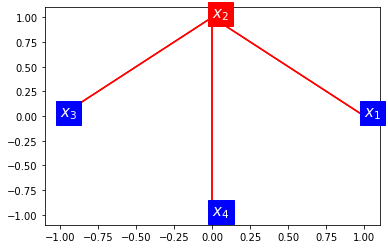

```python
# Exemple avec une matrice non orienté à 4 sommets

dessineGraphe([[0, 1, 0, 0],
               [1, 0, 1, 1],
               [0, 1, 0, 0],
               [0, 1, 0, 0]])
```

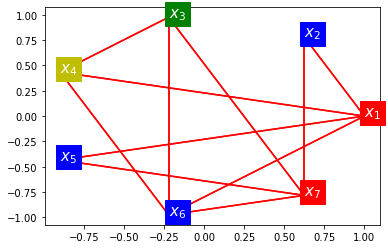

```python
# Exemple avec une matrice non orienté à 7 sommets

dessineGraphe([[0, 1, 0, 1, 1, 1, 0],
               [1, 0, 0, 0, 0, 0, 1],
               [0, 0, 0, 1, 0, 1, 1],
               [1, 0, 1, 0, 0, 1, 0],
               [1, 0, 0, 0, 0, 0, 1],
               [1, 0, 1, 1, 0, 0, 1],
               [0, 1, 1, 0, 1, 1, 0]])
```

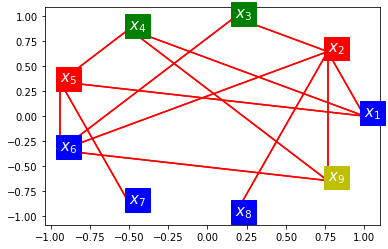

```python
# Exemple avec une matrice non orienté à 9 sommets

dessineGraphe([[0, 1, 0, 1, 1, 0, 0, 0, 0],
               [1, 0, 1, 0, 0, 1, 0, 1, 1],
               [0, 1, 0, 0, 0, 1, 0, 0, 0],
               [1, 0, 0, 0, 1, 0, 0, 0, 1],
               [1, 0, 0, 1, 0, 1, 1, 0, 0],
               [0, 1, 1, 0, 1, 0, 0, 0, 1],
               [0, 0, 0, 0, 1, 0, 0, 0, 0],
               [0, 1, 0, 0, 0, 0, 0, 0, 0],
               [0, 1, 0, 1, 0, 1, 0, 0, 0]])
```

# Fonctions réunies

Nous avons fait usage d'une fonction fournie par M. David Hébert permettant de générer la matrice d'un graphe non-orienté, prenant en paramètre un nombre de sommets `n`.

```python
def GrapheRand(n, p=0.5, valMax=1) :
    res=[]
    for i in range(n) :
        res.append([])
        for j in range(n) :
            res[i].append(0)
    for i in range(n) :
        for j in range(i+1, n) :
            if(random()<p) :
                res[i][j]=randint(1, valMax)
                res[j][i]=res[i][j]
    return res
```

```python
affichageMatrice(GrapheRand(7))
```

```
[0, 0, 0, 1, 0, 1, 0]
[0, 0, 1, 0, 1, 1, 0]
[0, 1, 0, 0, 1, 0, 0]
[1, 0, 0, 0, 0, 0, 0]
[0, 1, 1, 0, 0, 1, 0]
[1, 1, 0, 0, 1, 0, 0]
[0, 0, 0, 0, 0, 0, 0]
```

Nous avons créer une fonction `colorationBrelaz(matrice)` qui prend en paramètre une matrice et qui affiche le résultat de l'exécution de l'algorithme de Brelaz, avec le tableau de toutes les DSATs et des couleurs pour chaque sommets, ainsi que le résultat sous forme graphique.

Cette fonction réunit donc les plusieurs fonctions que nous avons défini en une seule fonction d'affichage.

```python
def colorationBrelaz(matrice) :
    affichageTabBrelaz(brelaz(matrice))
    dessineGraphe(matrice)
```

```
Som   x2 x5 x3 x4 x1
DSAT1  4  3  2  2  1
DSAT2  0  1  1  1  1
DSAT3  0  0  2  2  1
DSAT4  0  0  0  2  1
DSAT5  0  0  0  0  1
Coul   1  2  3  3  2
```

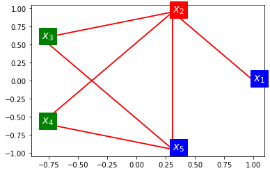

```python
colorationBrelaz(GrapheRand(5))
```

```
Som   x6 x1 x4 x5 x2 x3 x7
DSAT1  5  4  4  4  3  3  3
DSAT2  0  1  1  1  1  3  1
DSAT3  0  2  2  2  1  0  1
DSAT4  0  0  2  2  2  0  2
DSAT5  0  0  0  3  2  0  3
DSAT6  0  0  0  0  3  0  3
DSAT7  0  0  0  0  0  0  3
Coul   1  2  2  3  4  1  3
```

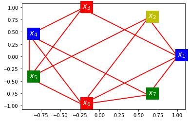

```python
colorationBrelaz(GrapheRand(7))
```

```
Som   x4 x3 x1 x5 x7 x2 x9 x6 x8
DSAT1  6  5  3  3  3  2  2  1  1
DSAT2  0  1  1  1  3  1  1  1  1
DSAT3  0  2  1  1  0  2  1  1  1
DSAT4  0  0  2  2  0  2  2  1  1
DSAT5  0  0  0  3  0  2  2  1  1
DSAT6  0  0  0  0  0  2  2  1  1
DSAT7  0  0  0  0  0  0  2  1  1
DSAT8  0  0  0  0  0  0  0  1  1
DSAT9  0  0  0  0  0  0  0  0  1
Coul   1  2  3  4  1  2  3  2  2
```

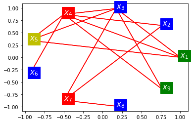

```python
colorationBrelaz(GrapheRand(9))
```

```
Som   x6 x7 x1 x4 x8 x10 x3 x11 x12 x2 x5 x9
DSAT1  7  7  6  6  5  5  4  4  4  3  3  2
DSAT2  0  1  1  6  1  5  1  4  1  1  3  1
DSAT3  0  2  1  0  1  1  2  1  2  2  3  1
DSAT4  0  2  2  0  1  1  2  2  2  3  0  1
DSAT5  0  2  2  0  1  1  2  2  2  0  0  1
DSAT6  0  0  3  0  2  2  2  3  3  0  0  1
DSAT7  0  0  0  0  3  3  2  4  3  0  0  1
DSAT8  0  0  0  0  4  4  2  0  3  0  0  1
DSAT9  0  0  0  0  0  4  3  0  4  0  0  1
DSAT10  0  0  0  0  0  0  3  0  4  0  0  1
DSAT11  0  0  0  0  0  0  3  0  0  0  0  1
DSAT12  0  0  0  0  0  0  0  0  0  0  0  1
Coul   1  2  3  1  5  5  2  4  3  2  1  2
```

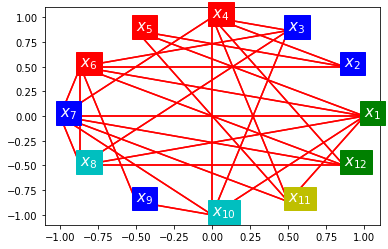

```python
colorationBrelaz(GrapheRand(12))
```